# week_11_binary_classification

## CMPINF 2100 Fall 2021 - Week 11

### Binary classification with logistic regression

## Import modules

```python
import numpy as np
import pandas as pd
import matplotlib.pyplot as plt

import seaborn as sns
```

## Read data

```python
data_path = 'week_11_example_data.csv'

df = pd.read_csv( data_path )
```

## EDA

```python
df.info()
```

```
<class 'pandas.core.frame.DataFrame'>
RangeIndex: 300 entries, 0 to 299
Data columns (total 6 columns):
 #   Column  Non-Null Count  Dtype
---  ------  --------------  -----
 0   x1      300 non-null    float64
 1   x2      300 non-null    float64
 2   x3      300 non-null    float64
 3   x4      300 non-null    float64
 4   x5      300 non-null    object
 5   y       300 non-null    int64
dtypes: float64(4), int64(1), object(1)
memory usage: 14.2+ KB
```

Check number of missings.

```python
df.isna().sum()
```

```
x1    0
x2    0
x3    0
x4    0
x5    0
y     0
dtype: int64
```

Check number of unique values.

```python
df.nunique()
```

```
x1    300
x2    300
x3    300
x4    300
x5      3
y       2
dtype: int64
```

Number of rows for each unique value of `x5`.

```python
df.x5.value_counts()
```

```
b    150
c     75
a     75
Name: x5, dtype: int64
```

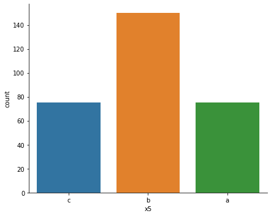

```python
sns.catplot(data = df, x='x5', kind='count', aspect=1.25)

plt.show()
```

Number of rows for each unique value of `y`.

```python
df.y.value_counts()
```

```
0    198
1    102
Name: y, dtype: int64
```

```python
df.y.value_counts(normalize=True)
```

```
0    0.66
1    0.34
Name: y, dtype: float64
```

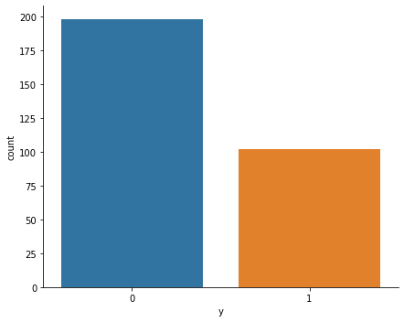

```python
sns.catplot(data = df, x='y', kind='count', aspect=1.25)

plt.show()
```

Continuous inputs, first check the ranges.

```python
df.describe()
```

|  | x1 | x2 | x3 | x4 | y |
| --- | --- | --- | --- | --- | --- |
| count | 300.000000 | 300.000000 | 300.000000 | 300.000000 | 300.0000 |
| mean | -0.000849 | 0.000261 | 0.002302 | 0.001372 | 0.3400 |
| std | 0.998805 | 1.000864 | 1.004086 | 1.001563 | 0.4745 |
| min | -2.913116 | -3.008946 | -2.783621 | -2.864881 | 0.0000 |
| 25% | -0.673919 | -0.671703 | -0.673862 | -0.673474 | 0.0000 |
| 50% | 0.000468 | -0.001799 | 0.001278 | 0.002178 | 0.0000 |
| 75% | 0.673103 | 0.671835 | 0.674558 | 0.670999 | 1.0000 |
| max | 2.783826 | 3.120873 | 3.497789 | 3.128220 | 1.0000 |

Or visualize with a boxplot.

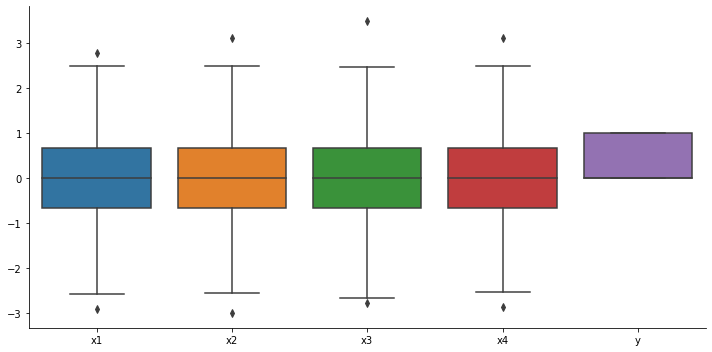

```python
sns.catplot(data = df, kind='box', aspect=2)

plt.show()
```

Look at the distributional shapes with violins.

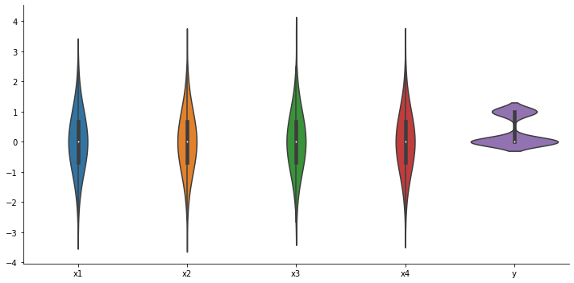

```python
sns.catplot(data = df, kind='violin', aspect=2)

plt.show()
```

Look at the *marginal* continuous variable distributions with histograms.

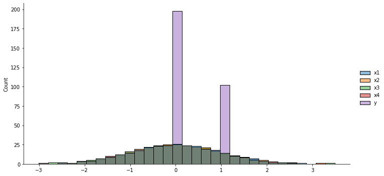

```python
sns.displot(data = df, kind='hist', aspect=2)

plt.show()
```

Tough to see...so separate into facets by first reshaping from wide to long format.

```python
lf = df.melt(id_vars=['y', 'x5'], value_vars = ['x1', 'x2', 'x3', 'x4'], ignore_index=True)
```

```python
lf.info()
```

```
<class 'pandas.core.frame.DataFrame'>
RangeIndex: 1200 entries, 0 to 1199
Data columns (total 4 columns):
 #   Column    Non-Null Count  Dtype
---  ------    --------------  -----
 0   y         1200 non-null   int64
 1   x5        1200 non-null   object
 2   variable  1200 non-null   object
 3   value     1200 non-null   float64
dtypes: float64(1), int64(1), object(2)
memory usage: 37.6+ KB
```

Compare the wide-format to the long-format data sets.

```python
df.head()
```

|  | x1 | x2 | x3 | x4 | x5 | y |
| --- | --- | --- | --- | --- | --- | --- |
| 0 | 1.077412 | -0.991094 | 0.208610 | -1.019744 | c | 1 |
| 1 | -0.637747 | -0.307506 | -1.794250 | 1.189993 | b | 0 |
| 2 | 1.345143 | -1.075281 | 1.685044 | 0.167879 | b | 0 |
| 3 | 1.659924 | 0.735156 | -0.210541 | -2.534105 | b | 1 |
| 4 | 1.182378 | 1.599140 | -0.301995 | 1.206648 | b | 0 |

```python
lf.head()
```

|  | y | x5 | variable | value |
| --- | --- | --- | --- | --- |
| 0 | 1 | c | x1 | 1.077412 |
| 1 | 0 | b | x1 | -0.637747 |
| 2 | 0 | b | x1 | 1.345143 |
| 3 | 1 | b | x1 | 1.659924 |
| 4 | 0 | b | x1 | 1.182378 |

Histograms for each continuous input.

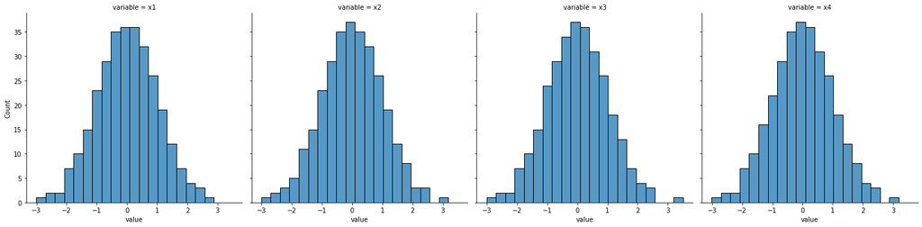

```python
sns.displot(data = lf, x='value', col='variable', kind='hist', bins=21)

plt.show()
```

Condition on the categorical input.

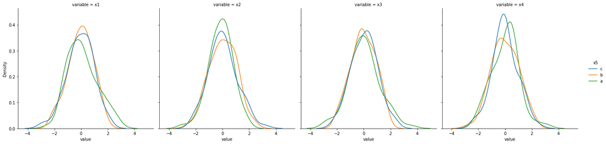

```python
sns.displot(data = lf, x='value', col='variable', hue='x5', kind='kde', common_norm=False)

plt.show()
```

Condition on the binary outcome.

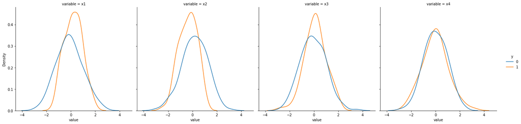

```python
sns.displot(data = lf, x='value', col='variable', hue='y', kind='kde', common_norm=False)

plt.show()
```

How many observations are present for each combination of the categorical input and the binary output?

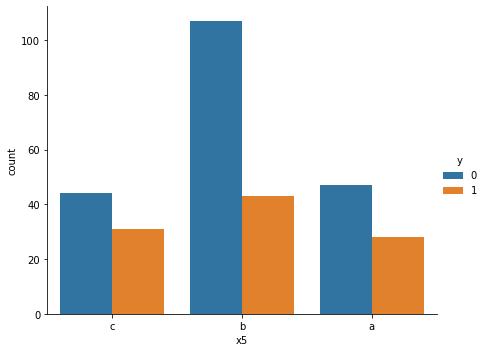

```python
sns.catplot(data = df, x='x5', hue='y', kind='count', aspect=1.25)

plt.show()
```

Condition the input distributions on both the categorical input and the binary output.

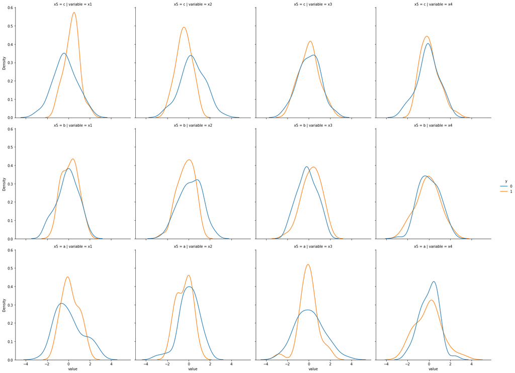

```python
sns.displot(data = lf, x='value', hue='y', col='variable', row='x5', kind='kde', common_norm=False)

plt.show()
```

Focus on the summary statistics via boxplots.

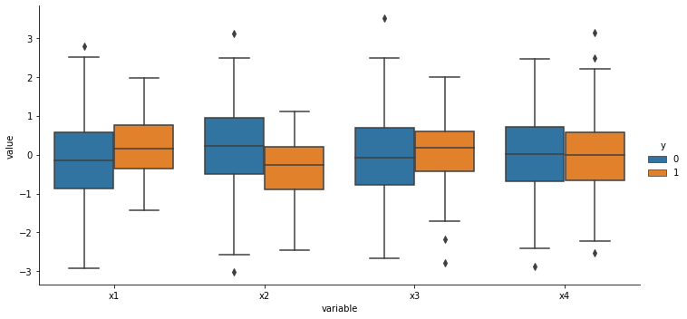

```python
sns.catplot(data = lf, x='variable', y='value', hue='y', kind='box', aspect=2)

plt.show()
```

Condition based on the categorical input.

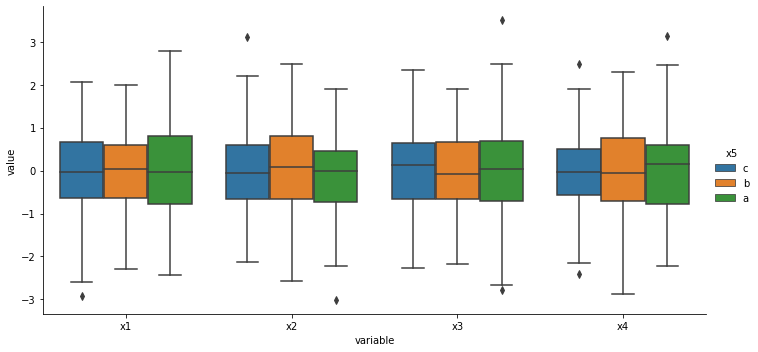

```python
sns.catplot(data = lf, x='variable', y='value', hue='x5', kind='box', aspect=2)

plt.show()
```

Condition on both the categorical input and the binary outcome.

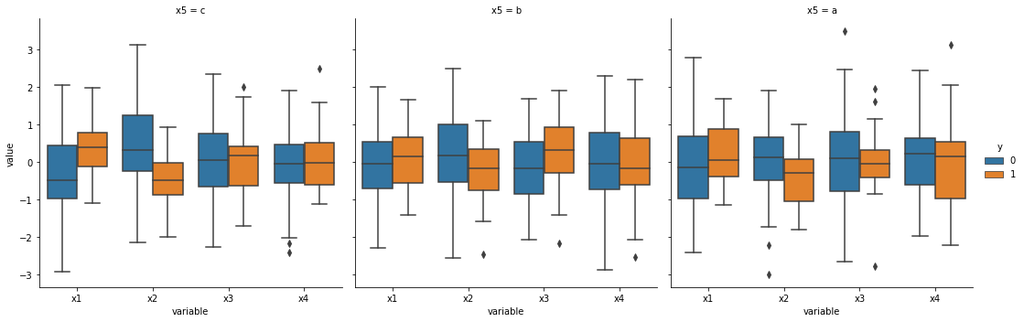

```python
sns.catplot(data = lf, x='variable', y='value', hue='y', col='x5', kind='box')

plt.show()
```

Focus on the average values per continuous input grouped by the binary outcome and the categorical input.

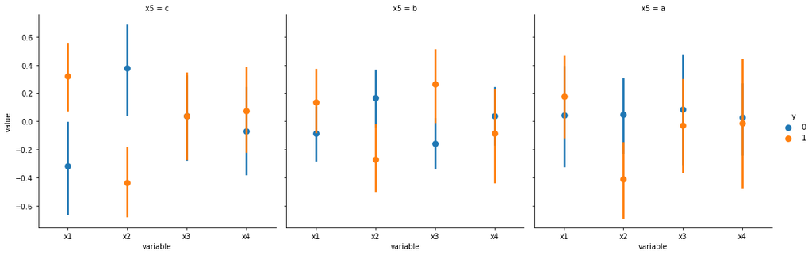

```python
sns.catplot(data = lf, x='variable', y='value', hue='y', col='x5', kind='point', ci=95, join=False)

plt.show()
```

Relationships between continuous inputs via pairsplot.

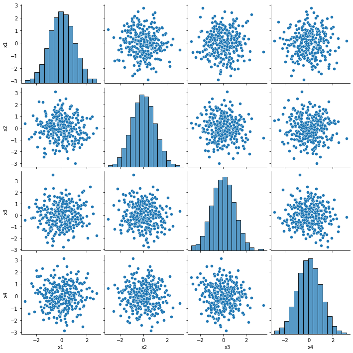

```python
sns.pairplot(data = df, vars=['x1', 'x2', 'x3', 'x4'])

plt.show()
```

Condition on the binary outcome.

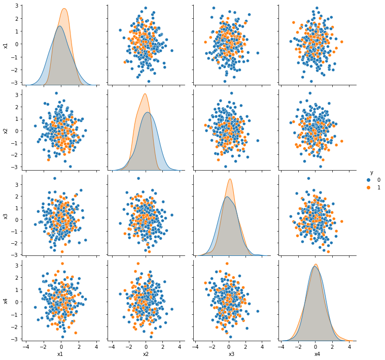

```python
sns.pairplot(data = df, hue='y', diag_kws={'common_norm': False})

plt.show()
```

Condition on the categorical input.

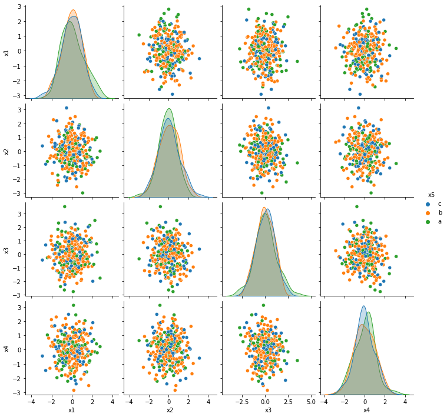

```python
sns.pairplot(data = df, vars=['x1', 'x2', 'x3', 'x4'], hue='x5', diag_kws={'common_norm': False})

plt.show()
```

Correlation plot to show the relationship between the continuous inputs.

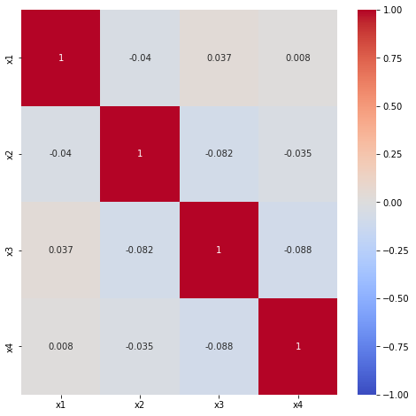

```python
fig, ax = plt.subplots(figsize=(8,8))

sns.heatmap(df.loc[:, ['x1', 'x2', 'x3', 'x4']].corr(),
            vmin=-1, vmax=1, center=0, annot=True,
            cmap='coolwarm',
            ax=ax)

plt.show()
```

Condition on the binary outcome.

```python
y_values = df.y.value_counts().index.to_list()

print( y_values )
```

```
[0, 1]
```

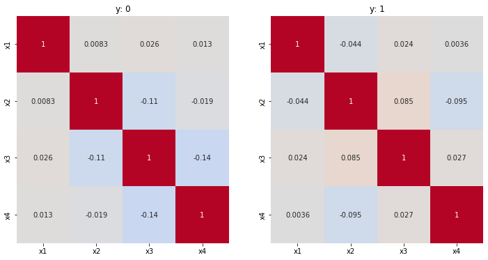

```python
fig, axs = plt.subplots(1, len(y_values), figsize=(12, 6))

for ix, aname in enumerate(y_values):
    sns.heatmap(data = df.groupby(['y']).corr().loc[aname],
                vmin=-1, vmax=1, center=0,
                annot=True,
                cmap='coolwarm', cbar=False,
                ax=axs[ix])

    axs[ix].set_title('y: '+str(aname))

plt.show()
```

Corrplot conditioned on each categorical input value.

```python
x5_values = df.x5.value_counts().index.to_list()

print( x5_values )
```

```
['b', 'c', 'a']
```

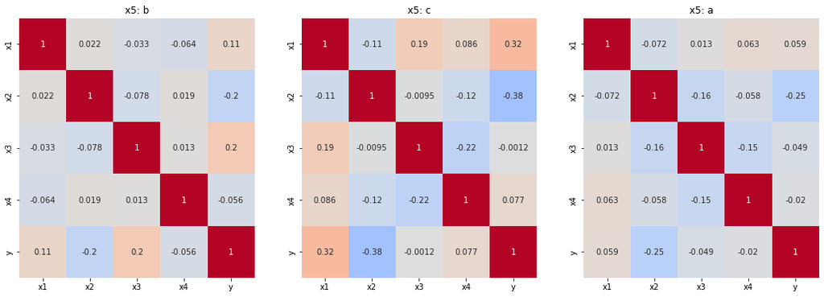

```python
fig, axs = plt.subplots(1, len(x5_values), figsize=(18, 6))

for ix, aname in enumerate(x5_values):
    sns.heatmap(data = df.groupby(['x5']).corr().loc[aname],
                vmin=-1, vmax=1, center=0,
                annot=True,
                cmap='coolwarm', cbar=False,
                ax=axs[ix])

    axs[ix].set_title('x5: '+aname)

plt.show()
```

Up to now we have kept the binary output, `y`, as an integer with values 0 or 1. This kind help streamline some of the calculations for visualization. For example, it's very easy to know the proportion of *events* in the data set. It's just the **mean** value for `y`!

```python
df.y.mean()
```

```
0.34
```

Check by filtering for `y==1`.

```python
df.loc[df.y == 1, :].shape[0] / df.shape[0]
```

```
0.34
```

We previously looked at the counts for combination of `y` and the categorical input, `x5`.

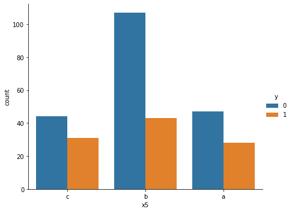

```python
sns.catplot(data = df, x='x5', hue='y', kind='count', aspect=1.25)

plt.show()
```

Can use Seaborn's point plot to calculate the event proportion per `x5` value.

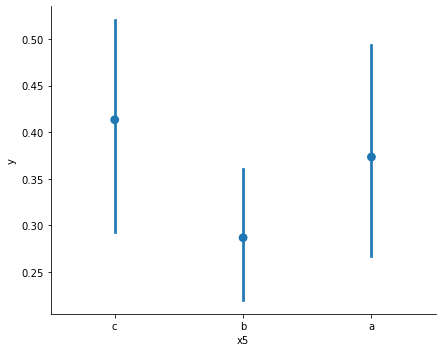

```python
sns.catplot(data = df, x='x5', y='y', kind='point', ci=95, join=False, aspect=1.25)

plt.show()
```

Check by grouping manually.

```python
df.groupby(['x5']).\
aggregate(num_rows = ('y', 'size'),
          num_events = ('y', 'sum'),
          prop_events = ('y', 'mean')).\
reset_index()
```

|  | x5 | num_rows | num_events | prop_events |
| --- | --- | --- | --- | --- |
| 0 | a | 75 | 28 | 0.373333 |
| 1 | b | 150 | 43 | 0.286667 |
| 2 | c | 75 | 31 | 0.413333 |

Relationship of the binary outcome with the continuous inputs. First visualize `y` vs `x1` using the wide-format data.

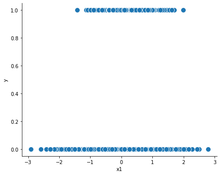

```python
sns.relplot(data = df, x='x1', y='y', aspect=1.25, s=100)

plt.show()
```

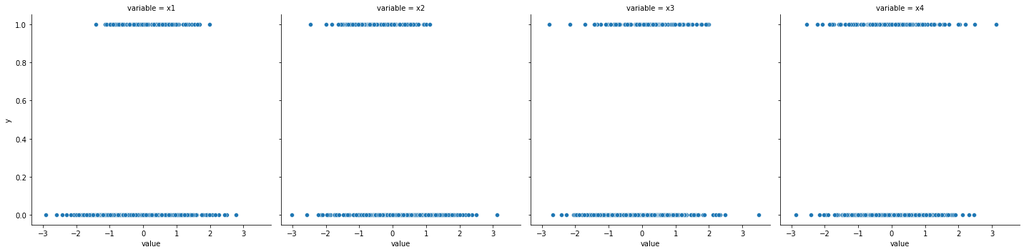

```python
sns.relplot(data = lf, x='value', y='y', col='variable')

plt.show()
```

Include a trend line with `sns.lmplot()`...we should **NEVER** make the plot below.

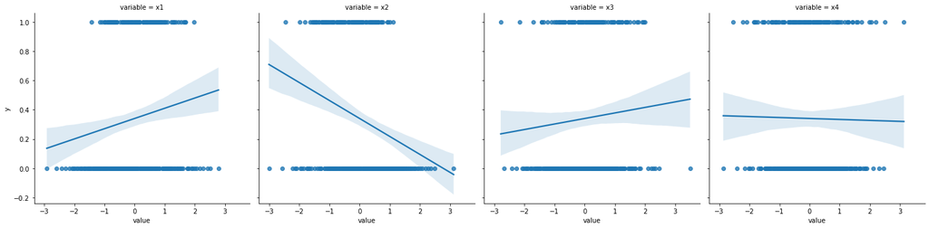

```python
sns.lmplot(data = lf, x='value', y='y', col='variable')

plt.show()
```

We need to make sure that the **probability** is always between 0 and 1. We can visualize the **logistic regression** smoother in Seaborn by setting `logistic=True`.

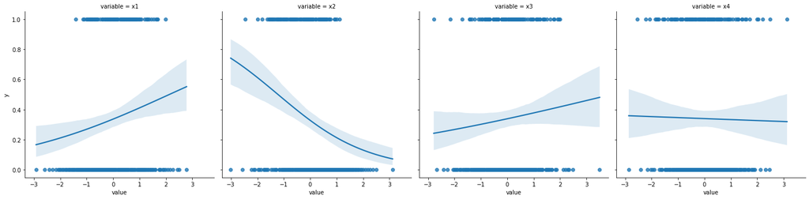

```python
sns.lmplot(data = lf, x='value', y='y', col='variable', logistic=True)

plt.show()
```

We can "jitter" or randomly perturb the y-axis position of the output just to help see the individual observations.

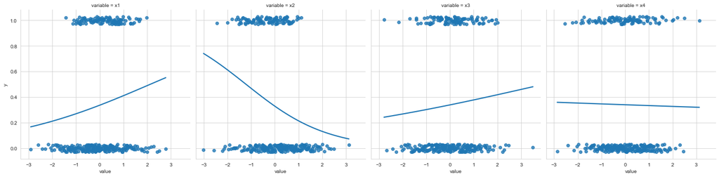

```python
sns.set_style('whitegrid')

sns.lmplot(data = lf, x='value', y='y', col='variable', logistic=True, ci=None, y_jitter=0.03)

plt.show()
```

Use the long-format data to show the logistic regression trend of the probability grouped by the categorical input.

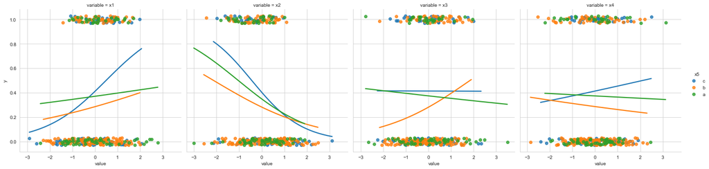

```python
sns.lmplot(data = lf, x='value', y='y', col='variable', hue='x5', logistic=True, ci=None, y_jitter=0.03)

plt.show()
```

## Fit logistic regression models

```python
import statsmodels.formula.api as smf
```

Start simple fit a model with all linear additive features with just the continuous inputs.

$$\log\left(\frac{\mathrm{Probability}_n}{1 - \mathrm{Probability}_n} \right) = \beta_0 + \beta_1 x_{n,1} + \beta_2 x_{n,2} + \beta_3 x_{n,3} + \beta_4 x_{n,4} $$

```python
fit_01 = smf.logit(formula = 'y ~ x1 + x2 + x3 + x4', data = df).fit()
```

```
Optimization terminated successfully.
         Current function value: 0.594506
         Iterations 5
```

```python
print( fit_01.summary() )
```

```
                           Logit Regression Results
==============================================================================
Dep. Variable:                      y   No. Observations:                  300
Model:                          Logit   Df Residuals:                      295
Method:                           MLE   Df Model:                            4
Date:                Thu, 11 Nov 2021   Pseudo R-squ.:                 0.07259
Time:                        19:21:53   Log-Likelihood:                -178.35
converged:                       True   LL-Null:                       -192.31
Covariance Type:            nonrobust   LLR p-value:                 1.296e-05
==============================================================================
                 coef    std err          z      P>|z|      [0.025      0.975]
------------------------------------------------------------------------------
Intercept     -0.7339      0.131     -5.620      0.000      -0.990      -0.478
x1             0.3105      0.130      2.396      0.017       0.057       0.564
x2            -0.5775      0.137     -4.227      0.000      -0.845      -0.310
x3             0.1236      0.129      0.959      0.337      -0.129       0.376
x4            -0.0470      0.129     -0.364      0.716      -0.300       0.206
==============================================================================
```

I prefer to visualize the coefficient summaries.

```python
def my_coefplot(model_object, figsize_use=(10,5)):
    fig, ax = plt.subplots(figsize=figsize_use)

    ax.errorbar(y = model_object.params.index,
                x = model_object.params,
                xerr = 2 * model_object.bse,
                fmt='o', color='black', ecolor='black',
                elinewidth=3, ms=10)

    ax.axvline(x=0, linestyle='--', linewidth=5, color='grey')

    ax.set_xlabel('coefficient value')

    plt.show()
```

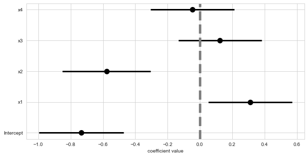

```python
my_coefplot(fit_01)
```

All pair-wise interactions between the continuous inputs.

```python
fit_02 = smf.logit(formula = 'y ~ (x1 + x2 + x3 + x4) ** 2', data = df).fit()
```

```
Optimization terminated successfully.
         Current function value: 0.587858
         Iterations 6
```

```python
print( fit_02.summary() )
```

```
                           Logit Regression Results
==============================================================================
Dep. Variable:                      y   No. Observations:                  300
Model:                          Logit   Df Residuals:                      289
Method:                           MLE   Df Model:                           10
Date:                Thu, 11 Nov 2021   Pseudo R-squ.:                 0.08296
Time:                        19:30:34   Log-Likelihood:                -176.36
converged:                       True   LL-Null:                       -192.31
Covariance Type:            nonrobust   LLR p-value:                 0.0004151
==============================================================================
                 coef    std err          z      P>|z|      [0.025      0.975]
------------------------------------------------------------------------------
Intercept     -0.7215      0.132     -5.459      0.000      -0.981      -0.462
x1             0.2932      0.136      2.163      0.031       0.028       0.559
x2            -0.5845      0.139     -4.210      0.000      -0.857      -0.312
x3             0.1545      0.137      1.126      0.260      -0.115       0.424
x4            -0.0322      0.132     -0.244      0.808      -0.292       0.227
x1:x2         -0.0466      0.151     -0.309      0.758      -0.342       0.249
x1:x3         -0.0079      0.129     -0.061      0.951      -0.260       0.245
x1:x4         -0.0478      0.134     -0.357      0.721      -0.310       0.214
x2:x3          0.1883      0.141      1.337      0.181      -0.088       0.464
x2:x4         -0.0839      0.139     -0.605      0.545      -0.356       0.188
x3:x4          0.1783      0.141      1.266      0.205      -0.098       0.454
==============================================================================
```

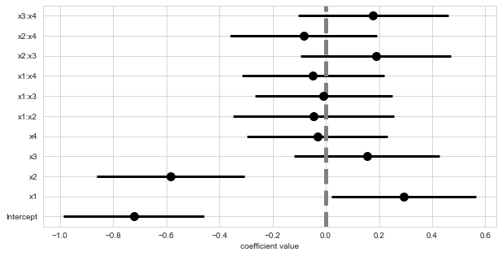

```python
my_coefplot( fit_02 )
```

Fit and print the summary for a model consisting just of `x2`.

```python
print( smf.logit(formula = 'y ~ x2', data = df).fit().summary() )
```

```
Optimization terminated successfully.
         Current function value: 0.606358
         Iterations 5
                           Logit Regression Results
==============================================================================
Dep. Variable:                      y   No. Observations:                  300
Model:                          Logit   Df Residuals:                      298
Method:                           MLE   Df Model:                            1
Date:                Thu, 11 Nov 2021   Pseudo R-squ.:                 0.05410
Time:                        19:40:56   Log-Likelihood:                -181.91
converged:                       True   LL-Null:                       -192.31
Covariance Type:            nonrobust   LLR p-value:                 5.080e-06
==============================================================================
                 coef    std err          z      P>|z|      [0.025      0.975]
------------------------------------------------------------------------------
Intercept     -0.7146      0.128     -5.574      0.000      -0.966      -0.463
x2            -0.5867      0.135     -4.334      0.000      -0.852      -0.321
==============================================================================
```

Fit a model consisting of the **categorical input** `x5`.

```python
df.dtypes
```

```
x1    float64
x2    float64
x3    float64
x4    float64
x5     object
y       int64
dtype: object
```

```python
fit_03 = smf.logit(formula = 'y ~ x5', data = df).fit()
```

```
Optimization terminated successfully.
         Current function value: 0.634259
         Iterations 5
```

```python
print( fit_03.summary() )
```

```
                           Logit Regression Results
==============================================================================
Dep. Variable:                      y   No. Observations:                  300
Model:                          Logit   Df Residuals:                      297
Method:                           MLE   Df Model:                            2
Date:                Thu, 11 Nov 2021   Pseudo R-squ.:                 0.01057
Time:                        19:42:31   Log-Likelihood:                -190.28
converged:                       True   LL-Null:                       -192.31
Covariance Type:            nonrobust   LLR p-value:                    0.1309
==============================================================================
                 coef    std err          z      P>|z|      [0.025      0.975]
------------------------------------------------------------------------------
Intercept     -0.5179      0.239     -2.170      0.030      -0.986      -0.050
x5[T.b]       -0.3937      0.299     -1.315      0.188      -0.980       0.193
x5[T.c]        0.1677      0.335      0.501      0.616      -0.488       0.824
==============================================================================
```

Work with **design matrix** to see the **dummy variables** that get created to support the categorical input.

```python
from patsy import dmatrices
```

```python
y03, X03 = dmatrices('y ~ x5', data = df, return_type='dataframe')
```

```python
print( type(y03) )

print( type(X03) )
```

```
<class 'pandas.core.frame.DataFrame'>
<class 'pandas.core.frame.DataFrame'>
```

```python
y03
```

|  | y |
| --- | --- |
| 0 | 1.0 |
| 1 | 0.0 |
| 2 | 0.0 |
| 3 | 1.0 |
| 4 | 0.0 |
| ... | ... |
| 295 | 0.0 |
| 296 | 0.0 |
| 297 | 0.0 |
| 298 | 1.0 |
| 299 | 1.0 |

300 rows × 1 columns

```python
X03
```

|  | Intercept | x5[T.b] | x5[T.c] |
| --- | --- | --- | --- |
| 0 | 1.0 | 0.0 | 1.0 |
| 1 | 1.0 | 1.0 | 0.0 |
| 2 | 1.0 | 1.0 | 0.0 |
| 3 | 1.0 | 1.0 | 0.0 |
| 4 | 1.0 | 1.0 | 0.0 |
| ... | ... | ... | ... |
| 295 | 1.0 | 0.0 | 1.0 |
| 296 | 1.0 | 0.0 | 1.0 |
| 297 | 1.0 | 1.0 | 0.0 |
| 298 | 1.0 | 1.0 | 0.0 |
| 299 | 1.0 | 1.0 | 0.0 |

300 rows × 3 columns

```python
X03.nunique()
```

```
Intercept    1
x5[T.b]      2
x5[T.c]      2
dtype: int64
```

```python
X03['x5[T.b]'].value_counts()
```

```
0.0    150
1.0    150
Name: x5[T.b], dtype: int64
```

```python
X03['x5[T.c]'].value_counts()
```

```
0.0    225
1.0     75
Name: x5[T.c], dtype: int64
```

Look at the counts for the values of `x5`.

```python
df.x5.value_counts()
```

```
b    150
c     75
a     75
Name: x5, dtype: int64
```

```python
X03.head()
```

|  | Intercept | x5[T.b] | x5[T.c] |
| --- | --- | --- | --- |
| 0 | 1.0 | 0.0 | 1.0 |
| 1 | 1.0 | 1.0 | 0.0 |
| 2 | 1.0 | 1.0 | 0.0 |
| 3 | 1.0 | 1.0 | 0.0 |
| 4 | 1.0 | 1.0 | 0.0 |

```python
df.head()
```

|  | x1 | x2 | x3 | x4 | x5 | y |
| --- | --- | --- | --- | --- | --- | --- |
| 0 | 1.077412 | -0.991094 | 0.208610 | -1.019744 | c | 1 |
| 1 | -0.637747 | -0.307506 | -1.794250 | 1.189993 | b | 0 |
| 2 | 1.345143 | -1.075281 | 1.685044 | 0.167879 | b | 0 |
| 3 | 1.659924 | 0.735156 | -0.210541 | -2.534105 | b | 1 |
| 4 | 1.182378 | 1.599140 | -0.301995 | 1.206648 | b | 0 |

```python
df.head(8)
```

|  | x1 | x2 | x3 | x4 | x5 | y |
| --- | --- | --- | --- | --- | --- | --- |
| 0 | 1.077412 | -0.991094 | 0.208610 | -1.019744 | c | 1 |
| 1 | -0.637747 | -0.307506 | -1.794250 | 1.189993 | b | 0 |
| 2 | 1.345143 | -1.075281 | 1.685044 | 0.167879 | b | 0 |
| 3 | 1.659924 | 0.735156 | -0.210541 | -2.534105 | b | 1 |
| 4 | 1.182378 | 1.599140 | -0.301995 | 1.206648 | b | 0 |
| 5 | -1.474407 | -0.526312 | 0.489012 | -1.975302 | a | 0 |
| 6 | 2.271333 | 0.819373 | 2.478346 | -0.152872 | a | 0 |
| 7 | -0.318989 | -1.021589 | -1.178638 | -0.058649 | b | 0 |

```python
X03.head(8)
```

|  | Intercept | x5[T.b] | x5[T.c] |
| --- | --- | --- | --- |
| 0 | 1.0 | 0.0 | 1.0 |
| 1 | 1.0 | 1.0 | 0.0 |
| 2 | 1.0 | 1.0 | 0.0 |
| 3 | 1.0 | 1.0 | 0.0 |
| 4 | 1.0 | 1.0 | 0.0 |
| 5 | 1.0 | 0.0 | 0.0 |
| 6 | 1.0 | 0.0 | 0.0 |
| 7 | 1.0 | 1.0 | 0.0 |

Let's make predictions and the logistic regression models predicts the **probability of the event**.

```python
df_copy = df.copy()
```

```python
df_copy['pred_probability_03'] = fit_03.predict( df )
```

```python
df_copy.head()
```

|  | x1 | x2 | x3 | x4 | x5 | y | pred_probability_03 |
| --- | --- | --- | --- | --- | --- | --- | --- |
| 0 | 1.077412 | -0.991094 | 0.208610 | -1.019744 | c | 1 | 0.413333 |
| 1 | -0.637747 | -0.307506 | -1.794250 | 1.189993 | b | 0 | 0.286667 |
| 2 | 1.345143 | -1.075281 | 1.685044 | 0.167879 | b | 0 | 0.286667 |
| 3 | 1.659924 | 0.735156 | -0.210541 | -2.534105 | b | 1 | 0.286667 |
| 4 | 1.182378 | 1.599140 | -0.301995 | 1.206648 | b | 0 | 0.286667 |

```python
df_copy.nunique()
```

```
x1                     300
x2                     300
x3                     300
x4                     300
x5                       3
y                        2
pred_probability_03      3
dtype: int64
```

```python
df_copy.pred_probability_03.value_counts()
```

```
0.286667    150
0.413333     75
0.373333     75
Name: pred_probability_03, dtype: int64
```

```python
df_copy.groupby(['x5', 'pred_probability_03']).size().reset_index(name='num_rows')
```

|  | x5 | pred_probability_03 | num_rows |
| --- | --- | --- | --- |
| 0 | a | 0.373333 | 75 |
| 1 | b | 0.286667 | 150 |
| 2 | c | 0.413333 | 75 |

Confirm the proportion of the event for each category.

```python
df.groupby(['x5']).aggregate(prop_events = ('y', 'mean')).reset_index()
```

|  | x5 | prop_events |
| --- | --- | --- |
| 0 | a | 0.373333 |
| 1 | b | 0.286667 |
| 2 | c | 0.413333 |

Next, consider the interpretation of the coefficients for the dummy variables.

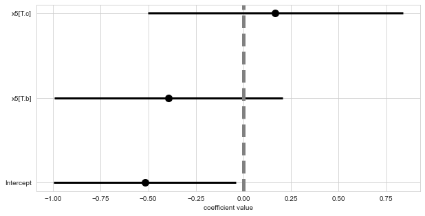

```python
my_coefplot(fit_03)
```

If we want to know the corresponding probability we need to convert from the log-odds value to the probability value.

```python
np.exp(-0.5) / (1 + np.exp(-0.5))
```

```
0.37754066879814546
```

Calculate the value associated with the `x5==c` dummy variable.

```python
np.exp(-0.5 + 0.17) / ( 1 + np.exp(-0.5 + 0.17))
```

```
0.4182406231581638
```

The dummy variable represents the **relative effect** from the reference level.

$$ \beta_0 + \beta_{x5b} x_{n, x5b} + \beta_{x5c} x_{, x5c} $$

When `x5 == 'c'`, the expression simplifies to:

$$ \beta_0 + \beta_{x5b} \times 0 + \beta_{x5c} \times 1$$$$ \beta_0 + \beta_{x5c} $$

If we do not want to work with dummy variables, if we want to work with the individual categories directly, we **must** remove the intercept and therefore work with **one-hot encoding** form of categorical variables.

```python
print( smf.logit(formula = 'y ~ x5 - 1', data = df).fit().summary() )
```

```
Optimization terminated successfully.
         Current function value: 0.634259
         Iterations 5
                           Logit Regression Results
==============================================================================
Dep. Variable:                      y   No. Observations:                  300
Model:                          Logit   Df Residuals:                      297
Method:                           MLE   Df Model:                            2
Date:                Thu, 11 Nov 2021   Pseudo R-squ.:                 0.01057
Time:                        20:16:39   Log-Likelihood:                -190.28
converged:                       True   LL-Null:                       -192.31
Covariance Type:            nonrobust   LLR p-value:                    0.1309
==============================================================================
                 coef    std err          z      P>|z|      [0.025      0.975]
------------------------------------------------------------------------------
x5[a]         -0.5179      0.239     -2.170      0.030      -0.986      -0.050
x5[b]         -0.9116      0.181     -5.049      0.000      -1.266      -0.558
x5[c]         -0.3502      0.234     -1.493      0.135      -0.810       0.109
==============================================================================
```

Visualizing the one-hot encoding coefficient summaries is not truly appropriate since we have to focus on the error bars **not** overlaping rather than if the confidence intervals contain 0 or not.

```
Optimization terminated successfully.
         Current function value: 0.634259
         Iterations 5
```

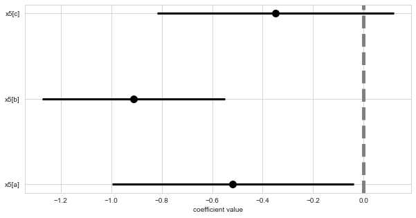

```python
my_coefplot( smf.logit(formula = 'y ~ x5 - 1', data = df).fit() )
```

```python
fit_one_hot = smf.logit( formula = 'y ~ x5 - 1', data = df).fit()
```

```
Optimization terminated successfully.
         Current function value: 0.634259
         Iterations 5
```

```python
fit_one_hot.params
```

```
x5[a]   -0.517943
x5[b]   -0.911629
x5[c]   -0.350202
dtype: float64
```

```python
fit_03.params
```

```
Intercept   -0.517943
x5[T.b]     -0.393686
x5[T.c]      0.167741
dtype: float64
```

```python
fit_03.params[0] + fit_03.params[1]
```

```
-0.9116287187683437
```